# Introduction to Data Visualization with R - AcqVA Aurora workshop - part 1

# Modifying lines & symbols

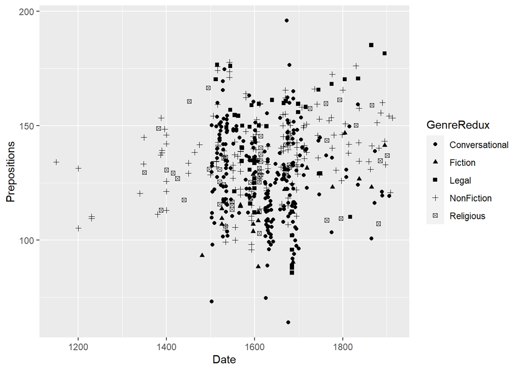

```r
ggplot(pdat, aes(x = Date, y = Prepositions, shape = GenreRedux)) +
  geom_point()
```

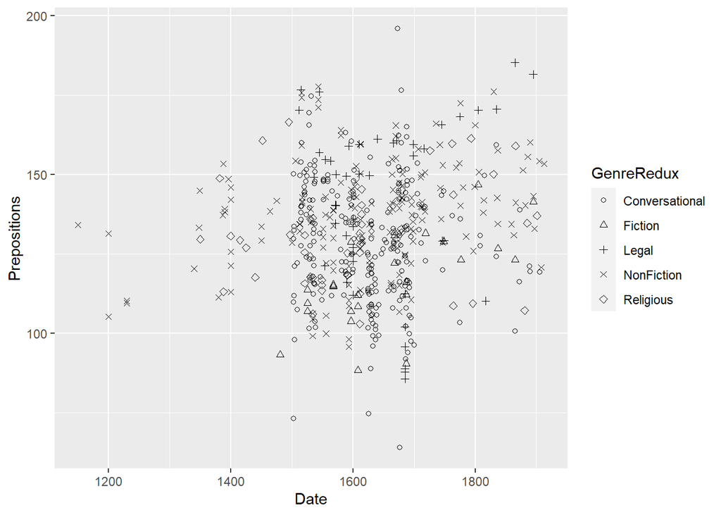

```r
ggplot(pdat, aes(x = Date, y = Prepositions)) +
  geom_point(aes(shape = GenreRedux)) +
  scale_shape_manual(values = 1:5)
```

Similarly, if you want to change the lines in a line plot, you define the `linetype` in the aesthetics.

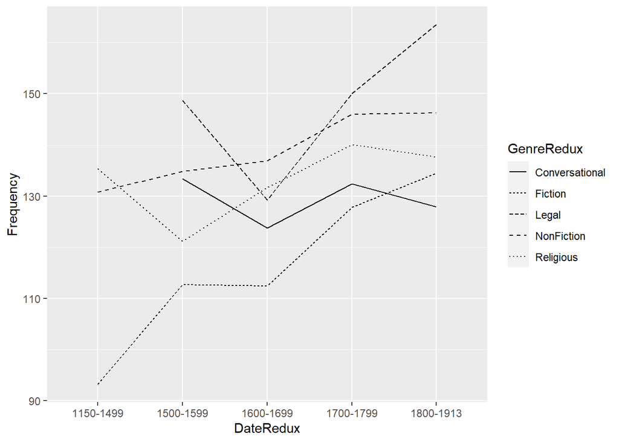

```r
pdat %>%
  dplyr::select(GenreRedux, DateRedux, Prepositions) %>%
  dplyr::group_by(GenreRedux, DateRedux) %>%
  dplyr::summarize(Frequency = mean(Prepositions)) %>%
  ggplot(aes(x = DateRedux, y = Frequency, group = GenreRedux, linetype = GenreRedux)) +
  geom_line()
```

You can of course also manually specify the line types.

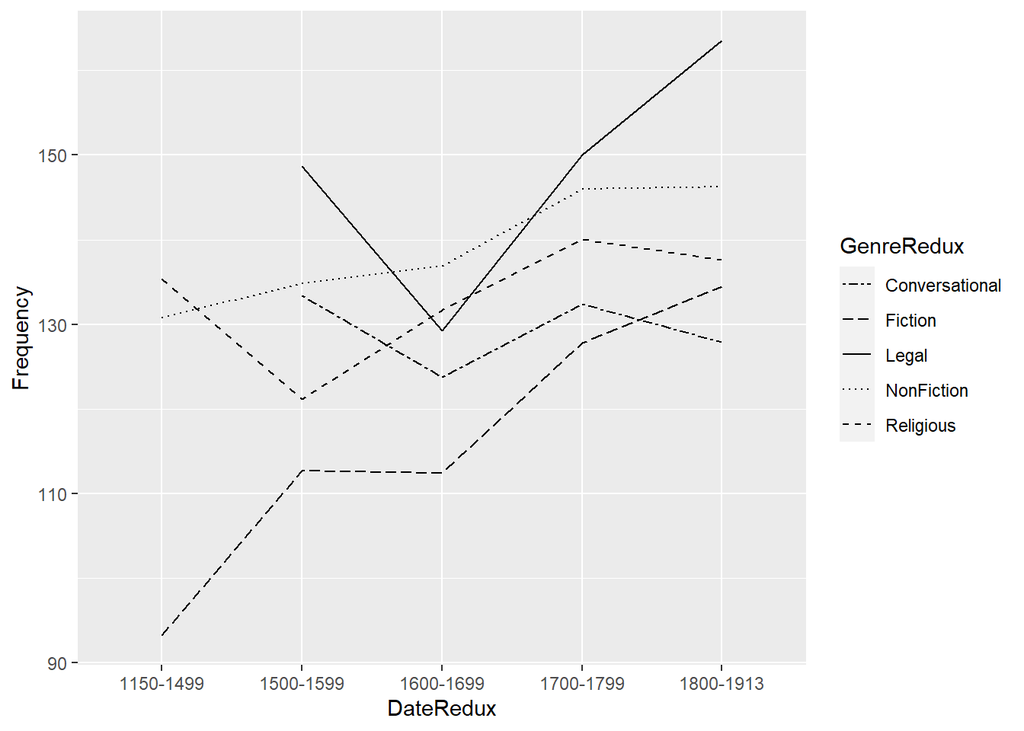

```r
pdat %>%
  dplyr::select(GenreRedux, DateRedux, Prepositions) %>%
  dplyr::group_by(GenreRedux, DateRedux) %>%
  dplyr::summarize(Frequency = mean(Prepositions)) %>%
  ggplot(aes(x = DateRedux, y = Frequency, group = GenreRedux, linetype = GenreRedux)) +
  geom_line() +
  scale_linetype_manual(values = c("twodash", "longdash", "solid", "dotted", "dashed"))
```

Here is an overview of the most commonly used linetypes in R.

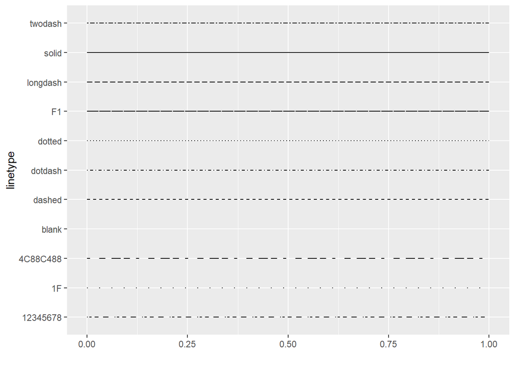

```r
d=data.frame(lt=c("blank", "solid", "dashed", "dotted", "dotdash", "longdash", "twodash", "1F", "F1", "4C88C488", "12345678"))
ggplot() +
scale_x_continuous(name="", limits=c(0,1)) +
scale_y_discrete(name="linetype") +
scale_linetype_identity() +
geom_segment(data=d, mapping=aes(x=0, xend=1, y=lt, yend=lt, linetype=lt))
```

To make your layers transparent, you need to specify `alpha` values.

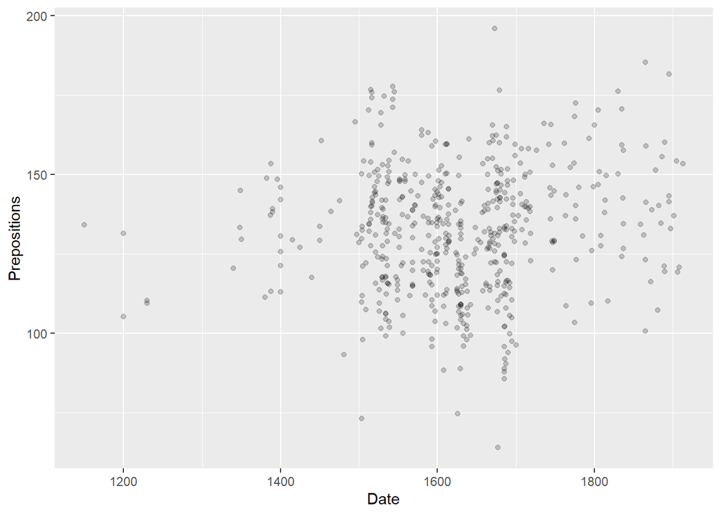

```r
ggplot(pdat, aes(x = Date, y = Prepositions)) +
  geom_point(alpha = .2)
```

Transparency can be particularly useful when using different layers that add different types of visualizations.

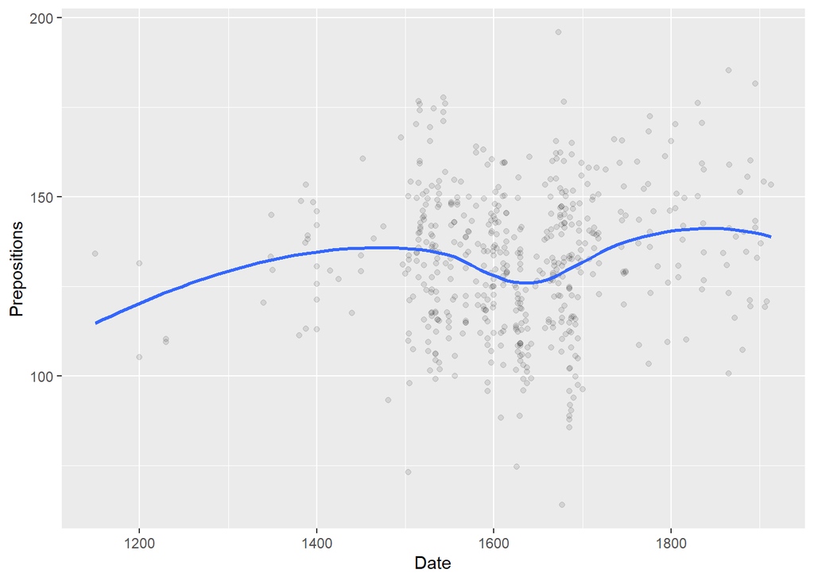

```r
ggplot(pdat, aes(x = Date, y = Prepositions)) +
  geom_point(alpha = .1) +
  geom_smooth(se = F)
```

Transparency can also be linked to other variables.

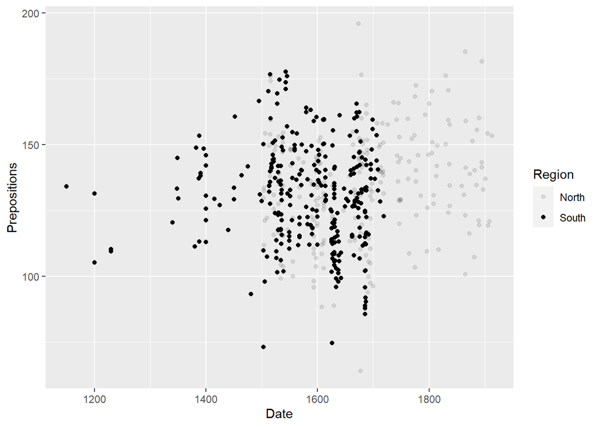

```r
ggplot(pdat, aes(x = Date, y = Prepositions, alpha = Region)) +
  geom_point()
```

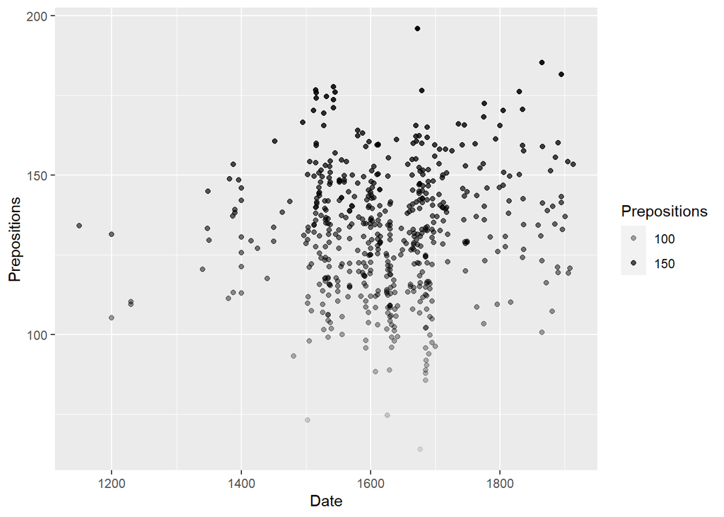

```r
ggplot(pdat, aes(x = Date, y = Prepositions, alpha = Prepositions)) +
  geom_point()
```